# Lecture Note: The F-Statistic and One-Way ANOVA

Dr. Rajitha M. Silva

## Introduction

In this lecture, we will explore the **F-Statistic** as used in Analysis of Variance (ANOVA). The F-Statistic allows us to test whether the means of three or more groups differ more than would be expected by random chance. While a t-test can compare two groups, ANOVA (and its associated F-Statistic) generalizes this for multiple groups.

Throughout this note, all examples will be drawn from the **sports world**. We will provide both **R** and **Python** code to:

1. Illustrate the decomposition of variance.
2. Compute the F-Statistic.
3. Conduct a One-Way ANOVA in R and Python.
4. Conduct Two-Way ANOVA (Two-Factor ANOVA) including model, interpretation, and examples.

## 1. Decomposition of Variance

Any observation $Y_{ij}$ can be thought of as the sum of:

1. The **grand mean** $\bar{Y}_{\cdot\cdot}$.
2. The **treatment (group) effect** $\tau_j$.
3. The **residual (error)** $\epsilon_{ij}$.

Mathematically, for group $j$ and observation $i$:
$$Y_{ij} = \bar{Y}_{\cdot\cdot} + \tau_j + \epsilon_{ij},$$
where: - $\bar{Y}_{\cdot\cdot}$ is the overall mean across all observations. - $\tau_j = \bar{Y}_{\cdot j} - \bar{Y}_{\cdot\cdot}$ is the effect of group $j$ (how group $j$’s mean deviates from the grand mean). - $\epsilon_{ij} = Y_{ij} - \bar{Y}_{\cdot j}$ is the deviation of observation $i$ in group $j$ from its group mean.

The F-Statistic is derived by comparing:

- The **between-group variance** (variance of the group means around the grand mean).
- The **within-group variance** (variance of observations within each group around their respective group means).

## 2. F-Statistic in One-Way ANOVA

#### 2.1 Formula

Given $k$ groups, with $n_j$ observations in group $j$ and total $N = \sum_{j=1}^k n_j$, define:

- **Sum of Squares Between (SSB)**:
  $$\text{SSB} = \sum_{j=1}^k n_j \left(\bar{Y}_{\cdot j} -
  \bar{Y}_{\cdot\cdot}\right)^2.$$
  Degrees of freedom: $\text{df}_{\text{between}} = k - 1$.
- **Sum of Squares Within (SSW)**:
  $$\text{SSW} = \sum_{j=1}^k \sum_{i=1}^{n_j} \left(Y_{ij} - \bar{Y}_{\cdot
  j}\right)^2.$$
  Degrees of freedom: $\text{df}_{\text{within}} = N - k$.

Compute:

- **Mean Square Between (MSB)**:
  $$\text{MSB} = \frac{\text{SSB}}{k - 1}.$$
- **Mean Square Within (MSW)**:
  $$\text{MSW} = \frac{\text{SSW}}{N - k}.$$
- The **F-Statistic**:
  $$F = \frac{\text{MSB}}{\text{MSW}}.$$
  Under the null hypothesis (all group means equal), $F$ follows an $F$-distribution with $(k - 1,\, N - k)$ degrees of freedom.

#### 2.2 Interpretation

- A large $F$-value indicates that the between-group variance is large relative to the within-group variance, suggesting at least one group mean differs.
- We compute a **p-value** by comparing the observed $F$-value to the $F$-distribution. If $p < \alpha$ (e.g., 0.05), we reject the null hypothesis of equal means.

## 3. Sports Example 1: Comparing Batting Averages Across Three Baseball Teams

Suppose we collect the batting averages of 10 randomly selected players from each of three teams: **Team A**, **Team B**, and **Team C**. We want to test if the mean batting average is the same across all three teams.

1. **Team A**:
   - Sample of 10 players.
   - Batting averages (in decimal form, e.g., 0.275).
2. **Team B**:
   - Sample of 10 players.
   - Batting averages.
3. **Team C**:
   - Sample of 10 players.
   - Batting averages.

Below is simulated data for illustration.

```r
## Simulate batting average data (10 players per team)
set.seed(2025)
team_A <- rnorm(10, mean = 0.280, sd = 0.020)
team_B <- rnorm(10, mean = 0.270, sd = 0.018)
team_C <- rnorm(10, mean = 0.290, sd = 0.022)

## Combine into a data frame
batting_df <- data.frame(
  average = c(team_A, team_B, team_C),
  team = factor(rep(c("A", "B", "C"), each = 10))
)

head(batting_df)
```

```
##     average team
## 1 0.2924151    A
## 2 0.2807128    A
## 3 0.2954631    A
## 4 0.3054498    A
## 5 0.2874195    A
## 6 0.2767429    A
```

#### 3.1 Compute One-Way ANOVA “by Hand” (Conceptual Steps)

1. **Compute group means** $\bar{Y}_{\cdot A}, \bar{Y}_{\cdot B}, \bar{Y}_{\cdot C}$.
2. **Compute grand mean** $\bar{Y}_{\cdot\cdot}$.
3. **Calculate SSB** and **SSW** using formulas from Section 2.
4. **Compute MSB = SSB / (k - 1)** and **MSW = SSW / (N - k)**.
5. **Compute $F = \frac{\text{MSB}}{\text{MSW}}$**.

#### 3.2 Compute One-Way ANOVA in R

```r
## Perform One-Way ANOVA in R
anova_result <- aov(average ~ team, data = batting_df)
summary(anova_result)
```

```
##             Df   Sum Sq   Mean Sq F value Pr(>F)
## team         2 0.002907 0.0014536   3.603  0.041 *
## Residuals   27 0.010894 0.0004035
## ---
## Signif. codes:  0 '***' 0.001 '**' 0.01 '*' 0.05 '.' 0.1 ' ' 1
```

- `aov(average ~ team, data = batting_df)` fits the One-Way ANOVA model.
- `summary(anova_result)` displays the ANOVA table, including Df, Sum Sq, Mean Sq, F value, and Pr(>F).

Interpretation: - If the **F value** is large and the **Pr(>F)** (p-value) is less than 0.05, we conclude that at least one team’s mean batting average differs from the others.

#### 3.3 Show One-Way ANOVA Code in Python

```python
import pandas as pd
import numpy as np
import statsmodels.api as sm
from statsmodels.formula.api import ols

## Create the same DataFrame in Python
np.random.seed(2025)
team_A_py = np.random.normal(loc=0.280, scale=0.020, size=10)
team_B_py = np.random.normal(loc=0.270, scale=0.018, size=10)
team_C_py = np.random.normal(loc=0.290, scale=0.022, size=10)

batting_py = pd.DataFrame({
    "average": np.concatenate([team_A_py, team_B_py, team_C_py]),
    "team": ["A"]*10 + ["B"]*10 + ["C"]*10
})

## Fit the One-Way ANOVA model
model = ols('average ~ C(team)', data=batting_py).fit()
anova_table = sm.stats.anova_lm(model, typ=1)
print(anova_table)
```

- The chunk is set with `eval=FALSE` to **show** the Python code without executing it.

## 4. Sports Example 2: Comparing Sprint Times Across Three Track Surfaces

Imagine we measure 100m sprint times (in seconds) for 8 athletes on three different surfaces: **Asphalt**, **Synthetic Track**, and **Grass**. We want to know if the average sprint time differs by surface.

```r
set.seed(2025)
asphalt <- rnorm(8, mean = 10.5, sd = 0.2)
synthetic <- rnorm(8, mean = 10.3, sd = 0.18)
grass <- rnorm(8, mean = 10.7, sd = 0.25)

sprint_df <- data.frame(
  time = c(asphalt, synthetic, grass),
  surface = factor(rep(c("Asphalt", "Synthetic", "Grass"), each = 8))
)

head(sprint_df)
```

```
##       time surface
## 1 10.62415 Asphalt
## 2 10.50713 Asphalt
## 3 10.65463 Asphalt
## 4 10.75450 Asphalt
## 5 10.57420 Asphalt
## 6 10.46743 Asphalt
```

#### 4.1 Compute One-Way ANOVA in R

```r
sprint_anova <- aov(time ~ surface, data = sprint_df)
summary(sprint_anova)
```

```
##             Df Sum Sq Mean Sq F value   Pr(>F)
## surface      2  1.368  0.6838   13.33 0.000183 ***
## Residuals   21  1.077  0.0513
## ---
## Signif. codes:  0 '***' 0.001 '**' 0.01 '*' 0.05 '.' 0.1 ' ' 1
```

#### 4.2 Show One-Way ANOVA Code in Python

```python
import pandas as pd
import numpy as np
import statsmodels.api as sm
from statsmodels.formula.api import ols

## Python DataFrame
np.random.seed(2025)
asphalt_py = np.random.normal(loc=10.5, scale=0.2, size=8)
synthetic_py = np.random.normal(loc=10.3, scale=0.18, size=8)
grass_py = np.random.normal(loc=10.7, scale=0.25, size=8)

sprint_py = pd.DataFrame({
    "time": np.concatenate([asphalt_py, synthetic_py, grass_py]),
    "surface": ["Asphalt"]*8 + ["Synthetic"]*8 + ["Grass"]*8
})

## Fit and get ANOVA table
model_sprint = ols('time ~ C(surface)', data=sprint_py).fit()
anova_sprint = sm.stats.anova_lm(model_sprint, typ=1)
print(anova_sprint)
```

## 5. Assumptions and Diagnostics

1. **Independence**: Observations in each group are independent.
2. **Normality**: Within each group, the residuals are approximately normally distributed.
3. **Homoscedasticity (Equal Variances)**: The variance within each group is roughly equal.

#### 5.1 Residual Diagnostics in R (Sports Example 1)

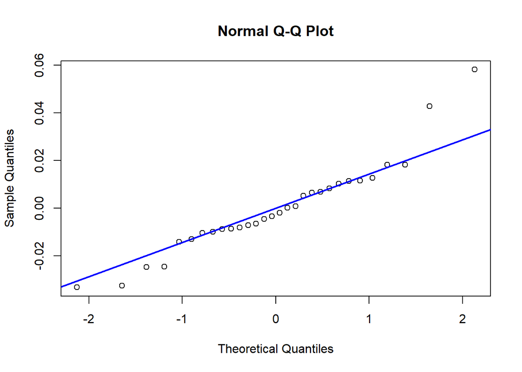

```r
## Extract residuals and fitted values
resid_vals <- residuals(anova_result)
fitted_vals <- fitted(anova_result)

## 1. Q-Q plot for normality
qqnorm(resid_vals)
qqline(resid_vals, col = "blue", lwd = 2)
```

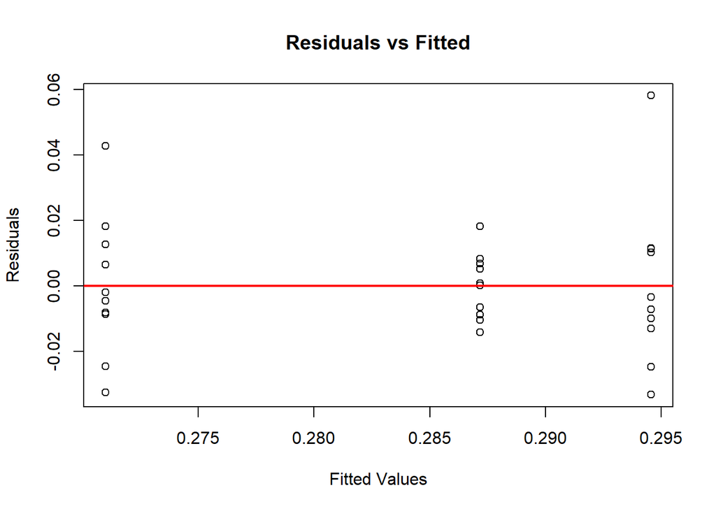

```r
## 2. Residuals vs Fitted for homoscedasticity
plot(fitted_vals, resid_vals,
     xlab = "Fitted Values",
     ylab = "Residuals",
     main = "Residuals vs Fitted")
abline(h = 0, col = "red", lwd = 2)
```

#### 5.2 Show Python Diagnostic Code

```python
import matplotlib.pyplot as plt
import scipy.stats as stats

## Obtain residuals and fitted values from previous model
resid_py = model.resid
fitted_py = model.fittedvalues

## 1. Q-Q plot
plt.figure()
stats.probplot(resid_py, dist="norm", plot=plt)
plt.title("Q-Q Plot of Residuals")
plt.show()

## 2. Residuals vs Fitted
plt.figure()
plt.scatter(fitted_py, resid_py)
plt.axhline(y=0, color='red', linestyle='--', linewidth=1.5)
plt.xlabel("Fitted Values")
plt.ylabel("Residuals")
plt.title("Residuals vs Fitted")
plt.show()
```

## 6. Post-Hoc Tests (If ANOVA is Significant)

When the overall ANOVA is significant, we often want to know **which pairs of groups** differ. A common post-hoc test is **Tukey’s Honest Significant Difference (HSD)**.

#### 6.1 Tukey HSD in R (Sports Example 1)

```r
TukeyHSD(anova_result)
```

```
##   Tukey multiple comparisons of means
##     95% family-wise confidence level
##
## Fit: aov(formula = average ~ team, data = batting_df)
##
## $team
##             diff          lwr         upr     p adj
## B-A -0.016183425 -0.038456541 0.006089691 0.1881685
## C-A  0.007388859 -0.014884257 0.029661975 0.6925341
## C-B  0.023572284  0.001299168 0.045845400 0.0364490
```

Interpretation: - Look at the confidence intervals and adjusted p-values for each pairwise comparison. If the interval does not contain 0, those two teams differ significantly.

#### 6.2 Show Tukey HSD Code in Python

```python
from statsmodels.stats.multicomp import pairwise_tukeyhsd

## Perform Tukey HSD
tukey = pairwise_tukeyhsd(endog=batting_py["average"],
                          groups=batting_py["team"],
                          alpha=0.05)
print(tukey)
```

## 7. Two-Way ANOVA (Two-Factor ANOVA)

Two-Way ANOVA allows us to assess the effect of **two categorical factors** (and their interaction) on a numeric outcome. For example, we might ask: *Does batting average depend on both **Team** and **Batting Order** simultaneously?*

#### 7.1 Model and Interpretation

Assume two factors: - Factor A: $A_i$ with levels $i = 1, 2, \dots, a$.  
- Factor B: $B_j$ with levels $j = 1, 2, \dots, b$.

The Two-Way ANOVA model with interaction is:
$$Y_{ijk} = \mu + \alpha_i + \beta_j + (\alpha\beta)_{ij} +
\epsilon_{ijk},$$
where: - $\mu$ is the overall mean.
- $\alpha_i$ is the effect of level $i$ of Factor A.
- $\beta_j$ is the effect of level $j$ of Factor B.
- $(\alpha\beta)_{ij}$ is the interaction effect when $A = i$ and $B = j$.
- $\epsilon_{ijk} \sim N(0, \sigma^2)$ is the random error.

###### Hypotheses

1. **Main effect of Factor A**:
   $$H_{0A}: \alpha_1 = \alpha_2 = \dots = \alpha_a = 0 \quad vs. \quad
   H_{1A}: \text{not all } \alpha_i = 0.$$
2. **Main effect of Factor B**:
   $$H_{0B}: \beta_1 = \beta_2 = \dots = \beta_b = 0 \quad vs. \quad H_{1B}:
   \text{not all } \beta_j = 0.$$
3. **Interaction effect**:
   $$H_{0AB}: (\alpha\beta)_{ij} = 0 \; \text{for all } i, j \quad vs. \quad
   H_{1AB}: \text{some } (\alpha\beta)_{ij} \neq 0.$$
- If the interaction is significant, it means the effect of one factor depends on the level of the other factor.

#### 7.2 Sports Example: Batting Average by Team and Batting Order

We simulate batting averages for players categorized by **Team** (A, B, C) and **Batting Order** (Top, Middle, Bottom).

```r
## Simulate balanced Two-Way ANOVA data
set.seed(2025)
teams <- rep(c("A", "B", "C"), each = 30)
orders <- rep(rep(c("Top", "Middle", "Bottom"), each = 10), times = 3)

## Simulate effects: base = 0.280, team effects, order effects, interaction noise
team_effects <- c(A = 0.000, B = -0.005, C = 0.005)
order_effects <- c(Top = 0.010, Middle = 0.000, Bottom = -0.010)

## Create batting averages with interaction noise
batting_two_df <- data.frame(
  average = 0.280 +
    team_effects[teams] +
    order_effects[orders] +
    rnorm(90, mean = 0, sd = 0.015),
  team = factor(teams),
  order = factor(orders)
)

head(batting_two_df)
```

```
##     average team order
## 1 0.2993114    A   Top
## 2 0.2905346    A   Top
## 3 0.3015973    A   Top
## 4 0.3090873    A   Top
## 5 0.2955646    A   Top
## 6 0.2875572    A   Top
```

###### 7.2.1 Two-Way ANOVA in R

```r
## Fit Two-Way ANOVA with interaction
anova_two <- aov(average ~ team * order, data = batting_two_df)
summary(anova_two)
```

```
##             Df   Sum Sq   Mean Sq F value   Pr(>F)
## team         2 0.000963 0.0004813   1.988    0.144
## order        2 0.005933 0.0029666  12.253 2.24e-05 ***
## team:order   4 0.000387 0.0000968   0.400    0.808
## Residuals   81 0.019611 0.0002421
## ---
## Signif. codes:  0 '***' 0.001 '**' 0.01 '*' 0.05 '.' 0.1 ' ' 1
```

- `team * order` requests main effects and interaction.
- The ANOVA table will show three rows:
  1. `team` (main effect)
  2. `order` (main effect)
  3. `team:order` (interaction)
  4. Residuals

###### 7.2.2 Interpreting the R Output

- If **`team`** row has p < 0.05: batting average differs by team, averaging over orders.
- If **`order`** row has p < 0.05: batting average differs by batting order, averaging over teams.
- If **`team:order`** row has p < 0.05: the effect of batting order differs across teams (interaction).

###### 7.2.3 Show Two-Way ANOVA Code in Python (No Execution)

```python
import pandas as pd
import numpy as np
import statsmodels.api as sm
from statsmodels.formula.api import ols

## Recreate the DataFrame in Python
np.random.seed(2025)
teams_py = np.repeat(["A", "B", "C"], 30)
orders_py = np.tile(np.repeat(["Top", "Middle", "Bottom"], 10), 3)

team_effects_py = {"A": 0.000, "B": -0.005, "C": 0.005}
order_effects_py = {"Top": 0.010, "Middle": 0.000, "Bottom": -0.010}

batting_two_py = pd.DataFrame({
    "average": 0.280 +
        [team_effects_py[t] for t in teams_py] +
        [order_effects_py[o] for o in orders_py] +
        np.random.normal(loc=0, scale=0.015, size=90),
    "team": teams_py,
    "order": orders_py
})

## Fit Two-Way ANOVA with interaction
model_two = ols('average ~ C(team) * C(order)', data=batting_two_py).fit()
anova_two_table = sm.stats.anova_lm(model_two, typ=2)
print(anova_two_table)
```

- `C(team) * C(order)` requests main effects and interaction in Python.
- `typ=2` stands for Type II sum of squares (common default for balanced designs).